# Cancer histology prediction challenge 2.0 (histpred2.0)

COMPTE RENDU

RAMDÉ Ismaïl - MCKENNA Kevin - EL Hadrami N’DOYE

2021-10-04

# 1 Package dependencies

- zip : to generate the zip files that contain the programs or the results to submit to the Codalab platform.

# 2 Format of the submission

- **For a code submission** : you have to make a zip file (no constrain on the namefile) that contains :
  - the file `metadata` that is generated by this script
  - your code inside a *R* file named `program.R`. This file will be sourced and have to contain :
    - a function `program` with `data_train` and `data_test` as argument : a matrix associated to your estimation.
  - any other files that you want to access from your function `program` : during the ingestion phase (when your code is evaluated), the working directory will be inside the directory obtained by unzipping your submission.
- **For a result submission** : you have to make a zip file (no constrain on the namefile), with your results as a matrix inside a rds file named `results.txt`.

# 3 Configuration of your result

```r
    ##
    ## EDIT THE FOLLOWING CODE BY COMMENTING/UNCOMMENTING THE REQUIRED PARTS
    ##

    ## define the public data set that you will use for your estimation :
    data_train <- readRDS(file = "data_train.rds")
    data_test <- readRDS(file = "data_test.rds")
```

# 4 Statistique descriptive

Nous commençons notre étude par une brève statistique descriptive afin de comprendre au mieux nos données ainsi que voir leur nature.

```r
# Dimensions
dim(data_train)
```

```
## [1]  546 1003
```

```r
dim(data_test)
```

```
## [1]  100 1003
```

```r
# Apperçu des données
head(data_train[,1:5])
```

```
##          sex   age histology    PRDM16    PRDM2
## train001   M 60.22        AD 10.013204 11.13085
## train002   F 55.36        AD  8.707926 10.97185
## train003   M 76.39        AD  9.663815 10.55224
## train004   M 73.40        SC  5.720395 12.48264
## train005   M 65.50        SC  5.180621 11.42484
## train006   M 64.56        SC  6.448264 11.07475
```

```r
# Table de l'histologie et du sexe
table(data_train$histology)
```

```
##
##  AD  SC
## 273 273
```

```r
table(data_train$sex)
```

```
##
##   F   M
## 211 335
```

## 4.1 Diagramme en bâton

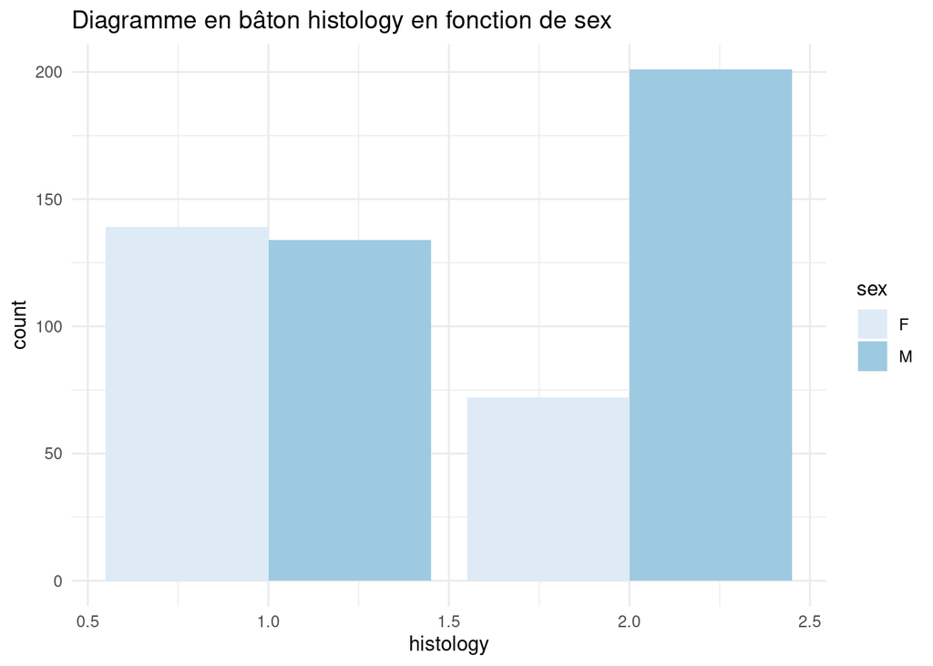

```r
library(ggplot2)
ggplot(data_train, aes(x=as.numeric(factor(histology)), fill=sex))+
  geom_bar(position=position_dodge())+
  scale_fill_brewer(palette="Blues")+
  labs(title="Diagramme en bâton histology en fonction de sex",
        x ="histology") +
  theme_minimal()
```

## 4.2 Distribution de l’expression de l’histologie (en fonction du sexe) dans la `data_train`

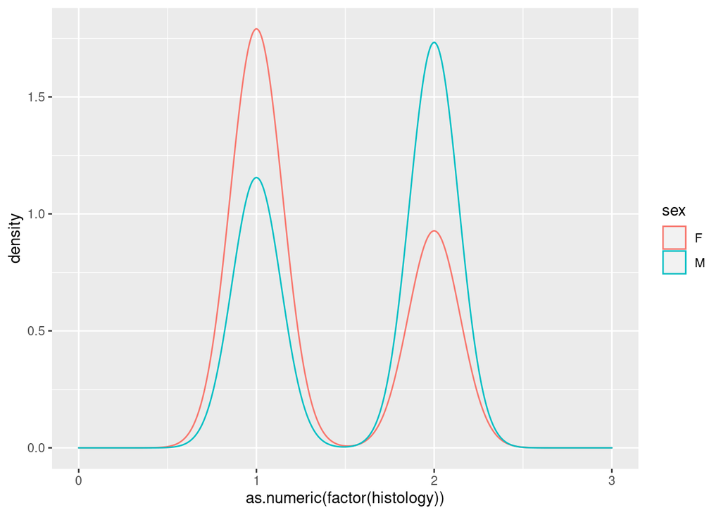

```r
library(ggplot2)
histology = as.numeric(factor(data_train$histology))
#layout(matrix(1:2, 1), respect=TRUE)
ggplot(data_train, aes(x=as.numeric(factor(histology)), color=sex)) +
  geom_density() +
  xlim(0,3)
```

```r
# Ajouter les moyennes
```

La figure ci-dessus illustre la densité de la variable ‘histology’ avec la part des hommes et des femmes.

# 5 Les méthodes de prédiction de la variable ‘histologie’

Dans ce projet nous utilisons essentiellement trois méthodes : 2 méthodes manuelles basées sur le $R²$ et les p-valeurs. Et une selection de variable. Dans les ligne qui suivent nous évaluérons l’efficacité de chacune d’elle.

**Volcano plot** … Nous avons d’abord classés les p-valeurs issues du test de Wald des différentes variable par ordre croissant. En suite nous decidons de selectionner les 50 premiers et calculons les les $R²$ pour chaque modèle. Sur le graphique on peut voir des sauts significatif de $R²$ des certains gènes. Ce sont ces gènes qui contribuent significativement à la prediction de la variable ‘histology’. Nous retenons donc les gènes : TINCR, PTHLH, UMPS, ALDH3B1, FRRS1, TOX3, ABCC6P1, HRAS, SYNCRIP, RNF185, NCK1, BCL11A, ZC3H8, MBIP, ELFN2, WDR72, TMTC1, JOSD1, MN1, EHD3.

# 6 Write a function to estimate the parameters of mean and covariance

```r
#' The function to estimate the mean and covariance parameters
#'
#' @param data_train a matrix
#' @param data_test a matrix
#' @return the estimated parameters
#' @examples
#' program(data_train = data_train, data_test = data_test)
program <- function(data_train, data_test) {
    gs = colnames(data_test)[-(1:3)]
    data_pred = data_test[,"histology"]
    names(data_pred) = rownames(data_test)
    data_train$histology = as.factor(data_train$histology)
    data_test$histology  = as.factor(data_test$histology )

    ##
    ## YOUR CODE BEGINS HERE




    # use the first gene as predictor for histology
    g = gs[1]
    plot(data_train$histology, data_train[,g])
    formula = as.formula(paste0("histology~", g))
    print(formula)
    m = glm(formula, data_train, family =binomial(link = 'logit'))
    pred = predict.glm(m, data_test, type="response")
    data_pred = ifelse(pred<0.5, "AD", "SC")

    # get gene with best logistic regression model as predictor for histology
    ms = sapply(gs, function(g){
      # print(g)
      formula = as.formula(paste0("histology~", g))
      m = glm(formula, data_train, family =binomial(link = 'logit'))

      pval = summary(m)$coefficients[2,4]
      beta = m$coefficients[[2]]
      return(c(pval=pval, beta=beta))
    })
    # estBeta <- summary(m)$coefficients[,1]
    # varBeta <- summary(m)$cov.unscaled
    # wald.test(Sigma = varBeta, b = estBeta, Terms = 500)
    plot(ms["beta",], -log10(ms["pval",]))
    g = colnames(ms[,order(ms["pval",])])[1:50]
    # tt = -log10(ms["pval",])
    # t = sort(tt)[1:50]
    # plot(t, col="red",main = "les 50 p-valeurs triées par ordre croissant")


    # 1. Méthode 1 (R2 les plus significatifs)
    ###########################################################################
    tt = (ms["pval",])
    tt
    sis_genes = names(sort(tt))
    R2 <- c()
    for(i in 1:50){
      formula2 <- as.formula(paste0("histology~",paste0(sis_genes[1:i],collapse="+")))
      model = glm(formula2,data_train,  family = binomial(logit))
      R2 <- c(R2, 1-(model$deviance/model$null.deviance))
    }
    layout(1, respect=TRUE)
    plot(1:50,R2,type="b",xlab="Nombre de gênes",main="R^2 en fonction du nombre de gênes sélectionnés")
    abline(v=3,lty=2,col=2)
    abline(v=4,lty=2,col=2)
    abline(v=5,lty=2,col=2)
    abline(v=7,lty=2,col=2)
    abline(v=8,lty=2,col=2)
    abline(v=9,lty=2,col=2)
    abline(v=15,lty=2,col=2)
    abline(v=20,lty=2,col=2)
    abline(v=26,lty=2,col=2)
    abline(v=27,lty=2,col=2)
    abline(v=37,lty=2,col=2)
    abline(v=46,lty=2,col=2)
    abline(v=44,lty=2,col=2)
    abline(v=43,lty=2,col=2)
    abline(v=43,lty=2,col=2)

    formula3 <- as.formula(paste0("histology~age+sex+",paste0(sis_genes[c(1:5,7,8,9,15,20,26,27,37,40,41,42,43,44,46,56)],collapse="+")))
    print(formula3)
    model2 <- glm(formula3,data_train,  family = binomial(logit))
    R_carre1 = 1-(model2$deviance/model2$null.deviance)
    R_carre1 # 0.9032166 et 4.0 sur Codalab
    ############


    # 2. Méthode 2 (Les Pvaleurs les plus significatifs au desssus du seuil 30)
    ############################################################################
    beta = ms["beta",]
    layout(1, respect=TRUE)
    plot(beta, -log10(tt), col="grey")
    idx = -log10(tt) > 30
    text(beta[idx], -log10(tt[idx]), names(beta[idx]))

    sis_genes2 = names(beta[idx])
    formula4 <- as.formula(paste0("histology~sex+age+",paste0(sis_genes2,collapse="+")))
    print(formula4)
    model3 <- glm(formula4,data_train,  family = binomial(logit))
    R_carre2 = 1-(model3$deviance/model3$null.deviance)
    R_carre2 # 0.9062056 et 0.5 sur codalab
    ##############


    # 3.Méthode 3 (Selection de variables)
    ####################################################
    nb_sis_genes = 40
    m_lo = glm(histology~1, data=data_train[,c("histology", sis_genes[1:nb_sis_genes])],family=binomial(logit))
    m_up = glm(histology~., data=data_train[,c("histology", sis_genes[1:nb_sis_genes])],family=binomial(logit))
    m_fwd = step(m_lo, dir="forward", scope=list(upper=m_up,lower=m_lo), trace=0)

    print(m_fwd$call)
    step_genes = names(m_fwd$coefficients)[-1]
    step_genes

    formula5 = as.formula(histology ~ PTHLH + EIF2B5 + SYNCRIP + RNF185 +
    ZC3H8 + DNMBP_AS1 + FRRS1 + HRAS + BCL11A + LMO7 + NCK1 +
    UMPS + MBIP)
    mod <- glm(formula = formula5, family = binomial(logit), data = data_train)
    mod$coefficients
    summary(mod)$coefficient
    z_val = summary(mod)$coefficient[2:7,3]
    statWald = z_val^2
    statWald
    pvalWald1 = 1-pchisq(statWald,1)
    pvalWald1
    rr = 1-(mod$deviance/mod$null.deviance)
    rr #  0.9146519
    ######################################################################"



    ms2 = ms[,order(ms["pval",])]
    g2= ''
    for (i in 1:(length(g)-1)){g2 = paste(g2,g[[i]],' + ')}
    g2 = paste(g2,g[[length(g)]])


    formula = as.formula(paste0("histology~", g2))
    print(formula)
    m = glm(formula5, data_train, family =binomial(link = 'logit'))
    pred = predict.glm(m, data_test, type="response")
    data_pred = ifelse(pred<0.5, "AD", "SC")



    ##
    ## YOUR CODE ENDS HERE
    ##

    return(data_pred)

}
```

# 7 Generate an estimation of the parameters of mean and covariance

```r
    ##
    ## DO NOT CHANGE THE FOLLOWING CODE
    ##

    ## we use the previously defined function 'program' to estimate A :
    data_pred <- program(
      data_train = data_train,
      data_test = data_test
    )
```

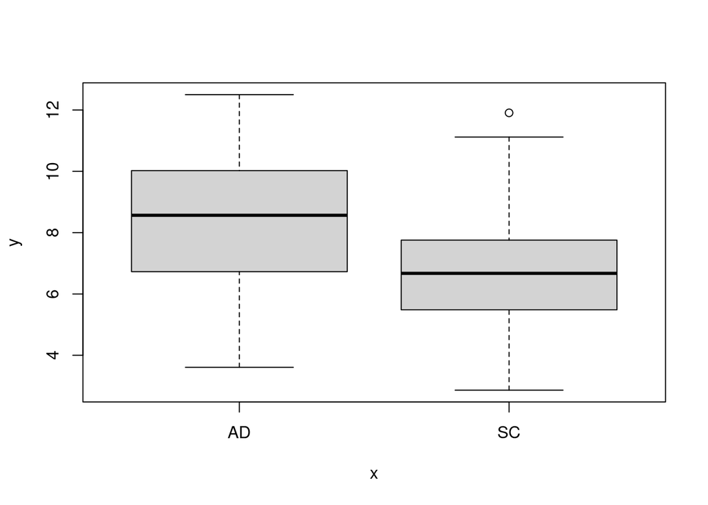

```
## histology ~ PRDM16
## <environment: 0x556cadc0fb60>
```

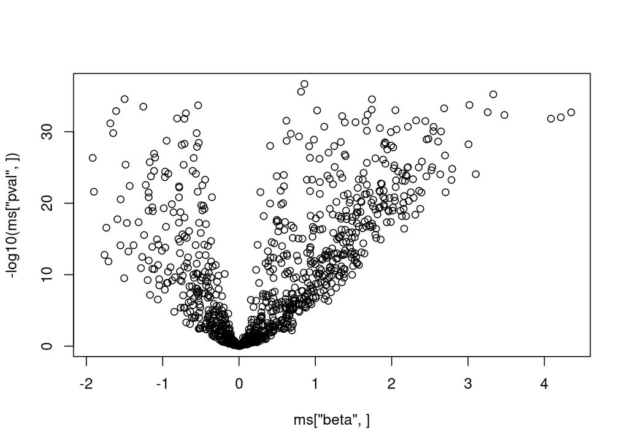

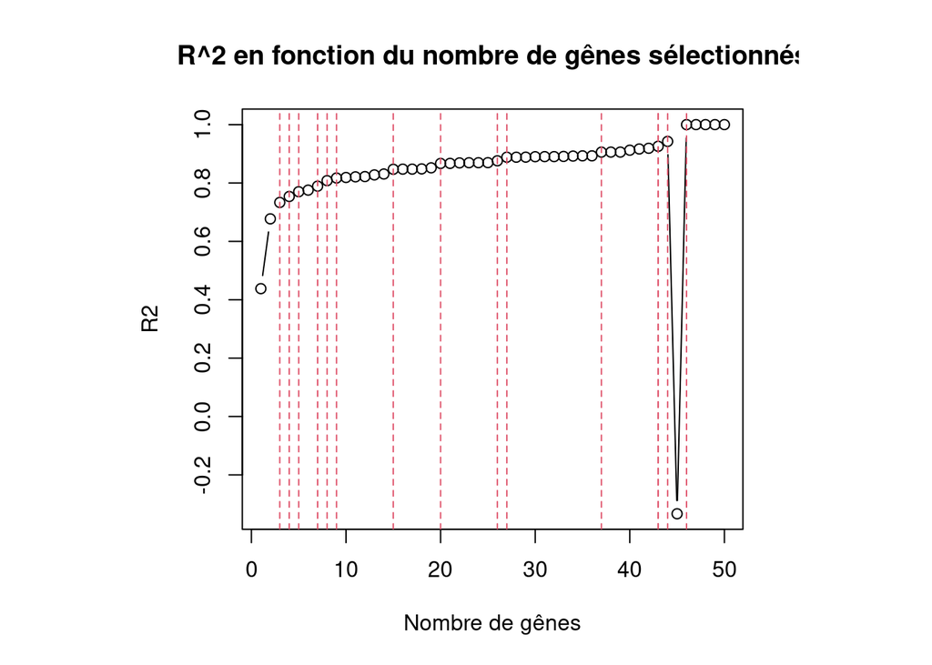

```
## histology ~ age + sex + TINCR + PTHLH + UMPS + ALDH3B1 + FRRS1 +
##     TOX3 + ABCC6P1 + HRAS + SYNCRIP + RNF185 + NCK1 + BCL11A +
##     ZC3H8 + MBIP + ELFN2 + WDR72 + TMTC1 + JOSD1 + MN1 + EHD3
## <environment: 0x556cadc0fb60>
```

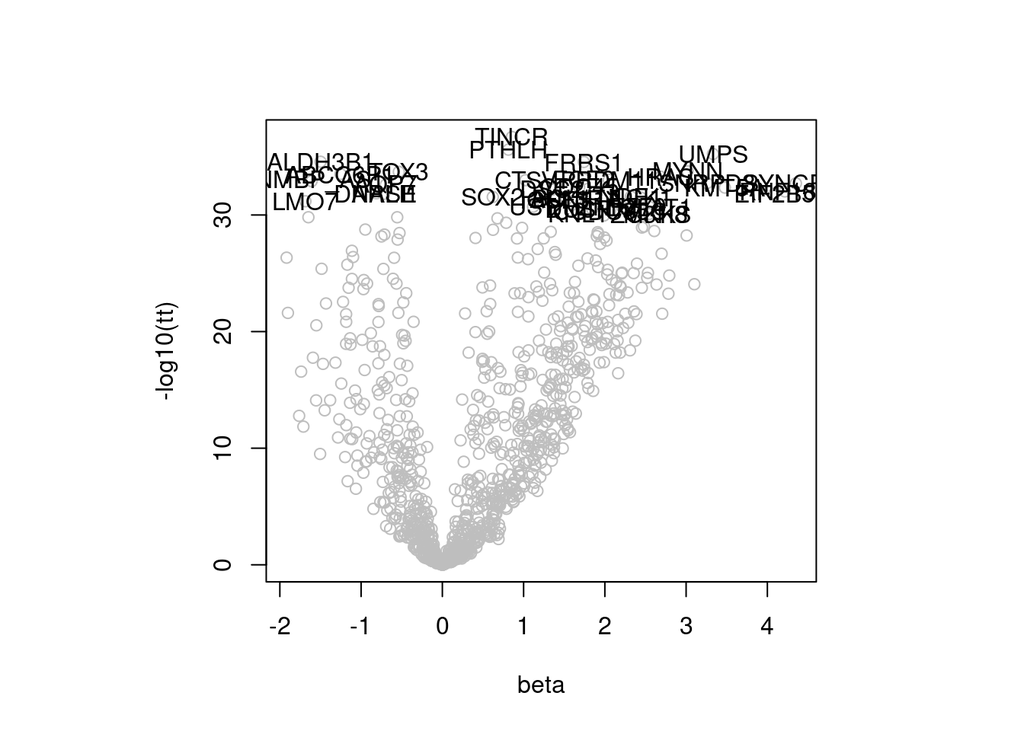

```
## histology ~ sex + age + PRDM11 + KMT5A + ECE2 + SNRPD3 + MKKS +
##     DNMBP_AS1 + NDE1 + RNF185 + FRRS1 + DUSP14 + HRAS + UST +
##     ZC3H8 + NCK1 + CTSV + CDC45 + EIF2B5 + SYNCRIP + AUNIP +
##     LMO7 + KNL1 + BCL11A + UMPS + ZNF770 + DNALI1 + LCLAT1 +
##     DSC2 + CCDC85C + MYNN + ALDH3B1 + IGSF3 + ABCC6P1 + SOX2 +
##     AQP7 + ARSE + TINCR + TOX3 + PTHLH
## <environment: 0x556cadc0fb60>
## glm(formula = histology ~ PTHLH + EIF2B5 + SYNCRIP + RNF185 +
##     ZC3H8 + DNMBP_AS1 + FRRS1 + HRAS + BCL11A + LMO7 + NCK1 +
##     UMPS + MBIP, family = binomial(logit), data = data_train[,
##     c("histology", sis_genes[1:nb_sis_genes])])
## histology ~ TINCR + PTHLH + UMPS + ALDH3B1 + FRRS1 + MYNN + TOX3 +
##     ABCC6P1 + HRAS + ECE2 + PRDM11 + CTSV + DNMBP_AS1 + SNRPD3 +
##     SYNCRIP + AQP7 + CDC45 + KMT5A + DSC2 + RNF185 + DNALI1 +
##     EIF2B5 + ARSE + NDE1 + SOX2 + NCK1 + BCL11A + AUNIP + IGSF3 +
##     LMO7 + UST + ZNF770 + LCLAT1 + DUSP14 + CCDC85C + KNL1 +
##     ZC3H8 + MKKS + EXT1 + MBIP + ELFN2 + WDR72 + TMTC1 + JOSD1 +
##     MARCKS + MN1 + UNC5CL + GJB2 + WDR5 + FRMD6_AS1
## <environment: 0x556cadc0fb60>
```

# 8 Generate a zip file with the ‘program’ source code

```r
if ( !dir.exists(paths = "submissions") ) {
    dir.create(path = "submissions")
}

## we save the source code as a R file named 'program.R' :
dump(
    list = c("program")
  , file = paste0("submissions", .Platform$file.sep, "program.R")
)
## we also generate the 'metadata' file
cat(
    "command: Rscript $program/program.R $input $output"
  , file = paste0("submissions", .Platform$file.sep, "metadata")
)

## we create the associated zip file :
zip_program <- paste0("submissions", .Platform$file.sep, "program_", format(x = Sys.time( ), format = "%Y_%m_%d_%S"), ".zip")
zip::zipr(
         zipfile = zip_program
       , files   = paste0("submissions", .Platform$file.sep, c("program.R", "metadata") )
     )
print(x = zip_program)
```

```
## [1] "submissions/program_2021_10_04_50.zip"
```

# 9 Generate a zip file with the estimation of the parameters of mean and covariance

```r
if ( !dir.exists(paths = "submissions") ) {
    dir.create(path = "submissions")
}

## we save the estimated A matrix as a rds file named 'results.txt' :
# saveRDS(
#     object = data_pred
#   , file   = paste0("submissions", .Platform$file.sep, "results.rds")
# )

write.table(
  x=data_pred,
  file= paste0("submissions", .Platform$file.sep, "results.txt"),
  quote=FALSE,
  row.names=FALSE,
  col.names=FALSE
)


## we create the associated zip file :
zip_results <- paste0("submissions", .Platform$file.sep, "results_", format(x = Sys.time( ), format = "%Y_%m_%d_%S"), ".zip")
zip::zipr(
         zipfile = zip_results
       , files   = paste0("submissions", .Platform$file.sep, c("results.txt") )
     )
print(x = zip_results)
```

```
## [1] "submissions/results_2021_10_04_50.zip"
```

# 10 Submit the zip file

It generates the files *submissions/program_2021_10_04_50.zip* and *submissions/results_2021_10_04_50.zip* (the 1st one for code submission, the 2nd one for result submission).

Submit the zip submission file on the challenge in the tab `Participate`, menu `Submit / View Results` menu, sub-menu `CHALLENGE #1`, by clicking the `Submit` button after filling out some metadatas.

On the codalab challenge web page, The *STATUS* become : - Submitting - Submitted  
- Running - Finished

When it’s finished : - You refresh the page and see your score - If enable, details for report could be downloaded by clicking *Download output from scoring step*. - Some logs are available to download. - Leader board is updated in the `Results` tab.